# cse-221710309057-Surapaneni sai meghana

# Problem statement:

"Predict behavior to retain customers. You can analyze all relevant customer data and develop focused customer retention programs." the final goal of the model is predict whether the customer is likely to churn or not

# 1.Importing required libraries and data from the source

```python
# importing the libraries intially
import pandas as pd
import numpy as np
```

```python
df=pd.read_csv("churn.csv")
df
```

|  | State | Account length | Area code | International plan | Voice mail plan | Number vmail messages | Total day minutes | Total day calls | Total day charge | Total eve minutes | Total eve calls | Total eve charge | Total night minutes | Total night calls | Total night charge | Total intl minutes | Total intl calls | Total intl charge | Customer service calls | Churn |
| --- | --- | --- | --- | --- | --- | --- | --- | --- | --- | --- | --- | --- | --- | --- | --- | --- | --- | --- | --- | --- |
| 0 | LA | 117 | 408 | No | No | 0 | 184.5 | 97 | 31.37 | 351.6 | 80 | 29.89 | 215.8 | 90 | 9.71 | 8.7 | 4 | 2.35 | 1 | False |
| 1 | IN | 65 | 415 | No | No | 0 | 129.1 | 137 | 21.95 | 228.5 | 83 | 19.42 | 208.8 | 111 | 9.40 | 12.7 | 6 | 3.43 | 4 | True |
| 2 | NY | 161 | 415 | No | No | 0 | 332.9 | 67 | 56.59 | 317.8 | 97 | 27.01 | 160.6 | 128 | 7.23 | 5.4 | 9 | 1.46 | 4 | True |
| 3 | SC | 111 | 415 | No | No | 0 | 110.4 | 103 | 18.77 | 137.3 | 102 | 11.67 | 189.6 | 105 | 8.53 | 7.7 | 6 | 2.08 | 2 | False |
| 4 | HI | 49 | 510 | No | No | 0 | 119.3 | 117 | 20.28 | 215.1 | 109 | 18.28 | 178.7 | 90 | 8.04 | 11.1 | 1 | 3.00 | 1 | False |
| ... | ... | ... | ... | ... | ... | ... | ... | ... | ... | ... | ... | ... | ... | ... | ... | ... | ... | ... | ... | ... |
| 662 | WI | 114 | 415 | No | Yes | 26 | 137.1 | 88 | 23.31 | 155.7 | 125 | 13.23 | 247.6 | 94 | 11.14 | 11.5 | 7 | 3.11 | 2 | False |
| 663 | AL | 106 | 408 | No | Yes | 29 | 83.6 | 131 | 14.21 | 203.9 | 131 | 17.33 | 229.5 | 73 | 10.33 | 8.1 | 3 | 2.19 | 1 | False |
| 664 | VT | 60 | 415 | No | No | 0 | 193.9 | 118 | 32.96 | 85.0 | 110 | 7.23 | 210.1 | 134 | 9.45 | 13.2 | 8 | 3.56 | 3 | False |
| 665 | WV | 159 | 415 | No | No | 0 | 169.8 | 114 | 28.87 | 197.7 | 105 | 16.80 | 193.7 | 82 | 8.72 | 11.6 | 4 | 3.13 | 1 | False |
| 666 | CT | 184 | 510 | Yes | No | 0 | 213.8 | 105 | 36.35 | 159.6 | 84 | 13.57 | 139.2 | 137 | 6.26 | 5.0 | 10 | 1.35 | 2 | False |

667 rows × 20 columns

# 2.Preprocessing the data with various techniques.

```python
df.describe()
```

|  | Account length | Area code | Number vmail messages | Total day minutes | Total day calls | Total day charge | Total eve minutes | Total eve calls | Total eve charge | Total night minutes | Total night calls | Total night charge | Total intl minutes | Total intl calls | Total intl charge | Customer service calls |
| --- | --- | --- | --- | --- | --- | --- | --- | --- | --- | --- | --- | --- | --- | --- | --- | --- |
| count | 667.000000 | 667.000000 | 667.000000 | 667.000000 | 667.000000 | 667.000000 | 667.000000 | 667.000000 | 667.000000 | 667.000000 | 667.000000 | 667.000000 | 667.000000 | 667.000000 | 667.000000 | 667.000000 |
| mean | 102.841079 | 436.157421 | 8.407796 | 180.948126 | 100.937031 | 30.761769 | 203.355322 | 100.476762 | 17.285262 | 199.685307 | 100.113943 | 8.985907 | 10.238381 | 4.527736 | 2.764948 | 1.563718 |
| std | 40.819480 | 41.783305 | 13.994480 | 55.508628 | 20.396790 | 9.436463 | 49.719268 | 18.948262 | 4.226160 | 49.759931 | 20.172505 | 2.239429 | 2.807850 | 2.482442 | 0.758167 | 1.333357 |
| min | 1.000000 | 408.000000 | 0.000000 | 25.900000 | 30.000000 | 4.400000 | 48.100000 | 37.000000 | 4.090000 | 23.200000 | 42.000000 | 1.040000 | 0.000000 | 0.000000 | 0.000000 | 0.000000 |
| 25% | 76.000000 | 408.000000 | 0.000000 | 146.250000 | 87.500000 | 24.860000 | 171.050000 | 88.000000 | 14.540000 | 167.950000 | 86.000000 | 7.560000 | 8.600000 | 3.000000 | 2.320000 | 1.000000 |
| 50% | 102.000000 | 415.000000 | 0.000000 | 178.300000 | 101.000000 | 30.310000 | 203.700000 | 101.000000 | 17.310000 | 201.600000 | 100.000000 | 9.070000 | 10.500000 | 4.000000 | 2.840000 | 1.000000 |
| 75% | 128.000000 | 415.000000 | 20.000000 | 220.700000 | 115.000000 | 37.520000 | 236.450000 | 113.000000 | 20.095000 | 231.500000 | 113.500000 | 10.420000 | 12.050000 | 6.000000 | 3.255000 | 2.000000 |
| max | 232.000000 | 510.000000 | 51.000000 | 334.300000 | 165.000000 | 56.830000 | 361.800000 | 168.000000 | 30.750000 | 367.700000 | 175.000000 | 16.550000 | 18.300000 | 18.000000 | 4.940000 | 8.000000 |

```python
df.info()
```

```
<class 'pandas.core.frame.DataFrame'>
RangeIndex: 667 entries, 0 to 666
Data columns (total 20 columns):
 #   Column                  Non-Null Count  Dtype
---  ------                  --------------  -----
 0   State                   667 non-null    object
 1   Account length          667 non-null    int64
 2   Area code               667 non-null    int64
 3   International plan      667 non-null    object
 4   Voice mail plan         667 non-null    object
 5   Number vmail messages   667 non-null    int64
 6   Total day minutes       667 non-null    float64
 7   Total day calls         667 non-null    int64
 8   Total day charge        667 non-null    float64
 9   Total eve minutes       667 non-null    float64
 10  Total eve calls         667 non-null    int64
 11  Total eve charge        667 non-null    float64
 12  Total night minutes     667 non-null    float64
 13  Total night calls       667 non-null    int64
 14  Total night charge      667 non-null    float64
 15  Total intl minutes      667 non-null    float64
 16  Total intl calls        667 non-null    int64
 17  Total intl charge       667 non-null    float64
 18  Customer service calls  667 non-null    int64
 19  Churn                   667 non-null    bool
dtypes: bool(1), float64(8), int64(8), object(3)
memory usage: 99.8+ KB
```

```python
#checking the no of rows
print ("Rows: " ,df.shape[0])
```

```
Rows:  667
```

```python
#checking the no of columns
print ("Columns: " ,df.shape[1])
```

```
Columns:  20
```

```python
#checking the features the data frame
print ("Features: \n" ,df.columns.tolist())
```

[output not shown]

```python
#checking the missing values
print ("Missing values:  ", df.isnull().sum().values.sum())
```

```
Missing values:   0
```

```python
#checking the unique values
print ("Unique values:  \n",df.nunique())
```

```
Unique values:
 State                      51
Account length            179
Area code                   3
International plan          2
Voice mail plan             2
Number vmail messages      37
Total day minutes         562
Total day calls           100
Total day charge          562
Total eve minutes         557
Total eve calls            94
Total eve charge          528
Total night minutes       568
Total night calls          96
Total night charge        453
Total intl minutes        132
Total intl calls           17
Total intl charge         132
Customer service calls      9
Churn                       2
dtype: int64
```

# Variable Breakdown

State: 51 Unique States in United States of America

Account Length: Length of The Account

Area Code :415 relates to San Francisco,408 is of San Jose and 510 is of City of Okland

International Plan: Yes Indicate International Plan is Present and No Indicates no subscription for International Plan

Voice Mail Plan :Yes Indicates Voice Mail Plan is Present and No Indicates no subscription for Voice Mail Plan

Number vmail messages: Number of Voice Mail Messages ranging from 0 to 50

Total day minutes: Total Number of Minutes Spent By Customers in Morning

Total day calls: Total Number of Calls made by Customer in Morning.

Total day charge :Total Charge to the Customers in Morning.

Total eve minutes:Total Number of Minutes Spent By Customers in Evening

Total eve calls: Total Number of Calls made by Customer in Evening.

Total night minutes :Total Number of Minutes Spent By Customers in the Night.

Total night calls :Total Number of Calls made by Customer in Night.

Total night charge: Total Charge to the Customers in Night.

# 3. Data visualization

### checking churn rate

here we check the churn rate using pie plot so that we can separate in the following

1. true- customers moved to another network
2. false- customers remained in the same network

```python
import io
import plotly.offline as py#visualization
py.init_notebook_mode(connected=True)#visualization
import plotly.graph_objs as go#visualization
import plotly.tools as tls#visualization
import plotly.figure_factory as ff#visualization
import matplotlib.pyplot as plt#visualization
from PIL import  Image
%matplotlib inline
import pandas as pd
import seaborn as sns#visualization
import itertools
import warnings
warnings.filterwarnings("ignore")
```

```python
#labels
lab = df["Churn"].value_counts().keys().tolist()
#values
val = df["Churn"].value_counts().values.tolist()

trace = go.Pie(labels = lab ,values = val ,marker = dict(colors =  [ 'blue' ,'green'],
                                                         line = dict(color = "white", width =  1.3)),
               rotation = 90,
               hoverinfo = "label+value+text", hole = .5)
layout = go.Layout(dict(title = "total percentage rate of churn",
                        plot_bgcolor  = "rgb(243,243,243)",
                        paper_bgcolor = "rgb(243,243,243)",
                       )
                  )

data = [trace]
fig = go.Figure(data = data,layout = layout)
py.iplot(fig)
```

[interactive chart not shown]

from the plot we an clearly understand that it is highly imbalaced data set.

```python
#Separating churn and non churn customers
churn     = df[df["Churn"] == bool(True)]
not_churn = df[df["Churn"] == bool(False)]
```

```python
#Dropping Account Length as it doesnt make a sense here
df = df.drop('Account length',axis=1)
```

```python
#Area Code
df['Area code'].unique()
```

```
array([408, 415, 510])
```

```python
#Replacing Yes/No values with 1 and 0
df['International plan'] = df['International plan'].replace({"Yes":1,"No":0}).astype(int)
df['Voice mail plan'] = df['Voice mail plan'].replace({"Yes":1,"No":0}).astype(int)
```

```python
print(df['International plan'] )#changed to 0 and 1
```

```
0      0
1      0
2      0
3      0
4      0
      ..
662    0
663    0
664    0
665    0
666    1
Name: International plan, Length: 667, dtype: int64
```

```python
print(df['Voice mail plan'])#changed to 0 and 1
```

```
0      0
1      0
2      0
3      0
4      0
      ..
662    1
663    1
664    0
665    0
666    0
Name: Voice mail plan, Length: 667, dtype: int64
```

# Checking Voice-Mail Feature

```python
#Voice-Mail Feature Messages
print('Unique vmail messages',df['Number vmail messages'].unique())
df['Number vmail messages'].describe()
```

```
Unique vmail messages [ 0 30 33 29 32 27 22 23 41 48 24 34 37 35 21 26 16 20 18 31 14 28 39 36
 45 51 38 11 19 15 25 40 49 17 42 13 46]
```

```
count    667.000000
mean       8.407796
std       13.994480
min        0.000000
25%        0.000000
50%        0.000000
75%       20.000000
max       51.000000
Name: Number vmail messages, dtype: float64
```

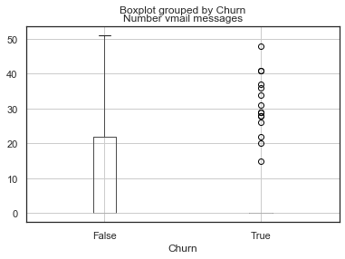

```python
import matplotlib.pyplot as plt
import numpy as np
%matplotlib inline
import matplotlib.pyplot as plt
import numpy as np
%matplotlib inline


plt.show()
df.boxplot(column='Number vmail messages', by='Churn')
```

- According to my hypothesis :
  1. Voice-Mail Service Upgradation
  2. Setting up a limit on Voice-Mail service strictly no more than 25 voice mails.
  3. Quality Drop in Voice-Mail after 25 voice mails.

# Total-Minutes in Morning Affecting the Churn Rate

```python
print('Maximum number of minutes:',df['Total day minutes'].max(),
      'i.e. Max number of Hours  spent:',round(df['Total day minutes'].max()/60))
print('Maximum number of minutes:',df['Total day minutes'].min())
print('Average number of minutes:',df['Total day minutes'].mean())
```

```
Maximum number of minutes: 334.3 i.e. Max number of Hours  spent: 6
Maximum number of minutes: 25.9
Average number of minutes: 180.94812593703156
```

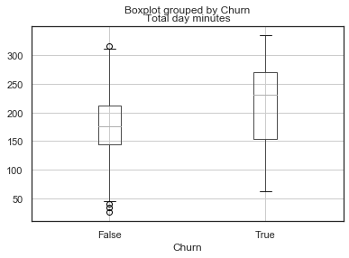

```python
import matplotlib.pyplot as plt
import numpy as np
%matplotlib inline


plt.show()
df.boxplot(column='Total day minutes', by='Churn')
```

We can infer from above box-plot that with users spending more 225 minutes or more i.e. approx 4hrs tend to switch to other operator.

- According to my hypothesis, following would be the factors that should be implemented:
  1. Network Disturbance during a Call
  2. Cracking sound or noise during a call
  3. Need to Upgrade or make smarter use of technologies like VoLTE to improve Voice Quality.
  4. Network Upgradation

```python
print('Maximum number of calls:',df['Total day calls'].max())
print('Minimum number of calls:',df['Total day calls'].min())
print('Average number of calls:',df['Total day calls'].mean())
```

```
Maximum number of calls: 165
Minimum number of calls: 30
Average number of calls: 100.93703148425787
```

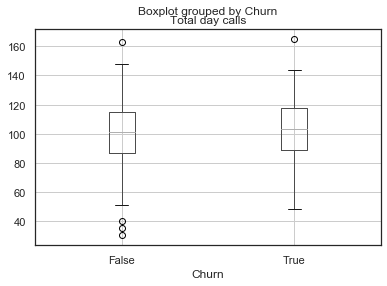

```python
plt.show()
df.boxplot(column='Total day calls', by='Churn')
```

We can infere here that on an average a 100 calls are made which is a good indication for the company.But we can also note that for the churn customer the median is slightly higher than 100 which indicates there are call drops which may lead to more calls in a morning.

```python
print('Maximum number of charge:',df['Total day charge'].max())
print('Minimum number of charge:',df['Total day charge'].min())
print('Average number of charge:',df['Total day charge'].mean())
```

```
Maximum number of charge: 56.83
Minimum number of charge: 4.4
Average number of charge: 30.761769115442267
```

Average charge is around 30$ which is a decent pricing strategy

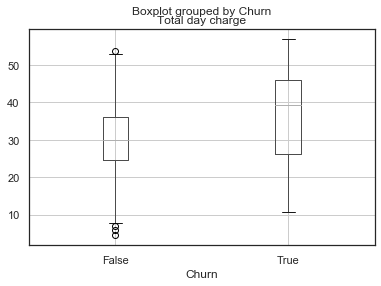

```python
plt.show()
df.boxplot(column='Total day charge', by='Churn')
```

Well,Here we can clearly indicate a strategy a good strategy to be implemented. As from above infered box-plots we can conclude one thing i.e Customers having more minutes spent on the network tend to leave the it's subscription and from the above box-plot it clearly indicates that there is defect in the pricing startegy of the company.

- According to my Hypothsis:
  1. Startegy of pricing needs to be re-evaluated.
  2. The Clients who have high call minutes and calls need a discount in the end.

# Evening time Affecting the Churn Rate

```python
print('Maximum number of minutes:',df['Total eve minutes'].max(),
      'i.e. Max number of Hours  spent:',round(df['Total eve minutes'].max()/60))
print('Maximum number of minutes:',df['Total eve minutes'].min())
print('Average number of minutes:',df['Total eve minutes'].mean())
```

```
Maximum number of minutes: 361.8 i.e. Max number of Hours  spent: 6
Maximum number of minutes: 48.1
Average number of minutes: 203.35532233883055
```

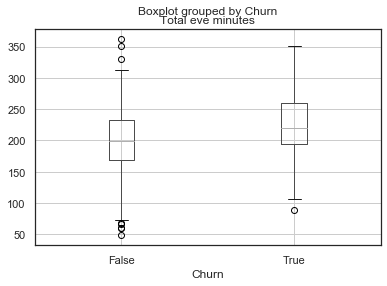

```python
plt.show()
df.boxplot(column='Total eve minutes', by='Churn')
```

```python
print('Maximum number of calls:',df['Total eve calls'].max())
print('Minimum number of calls:',df['Total eve calls'].min())
print('Average number of calls:',df['Total eve calls'].mean())
```

```
Maximum number of calls: 168
Minimum number of calls: 37
Average number of calls: 100.4767616191904
```

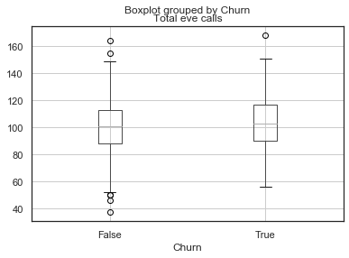

```python
plt.show()
df.boxplot(column='Total eve calls', by='Churn')
```

```python
print('Maximum number of charge:',df['Total eve charge'].max())
print('Minimum number of charge:',df['Total eve charge'].min())
print('Average number of charge:',df['Total eve charge'].mean())
```

```
Maximum number of charge: 30.75
Minimum number of charge: 4.09
Average number of charge: 17.285262368815594
```

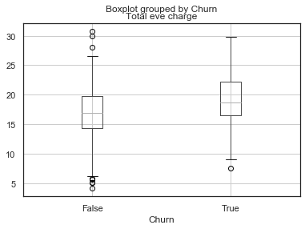

```python
plt.show()
df.boxplot(column='Total eve charge', by='Churn')
```

# Night Time Affecting Churn Rate

```python
print('Maximum number of minutes:',df['Total night minutes'].max(),'i.e. Max number of Hours  spent:',round(df['Total night minutes'].max()/60))
print('Minimum number of minutes:',df['Total night minutes'].min())
print('Average number of minutes:',df['Total night minutes'].mean())
```

```
Maximum number of minutes: 367.7 i.e. Max number of Hours  spent: 6
Minimum number of minutes: 23.2
Average number of minutes: 199.68530734632685
```

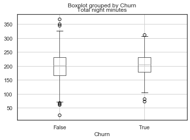

```python
plt.show()
df.boxplot(column='Total night minutes', by='Churn')
```

In Night, The Customers spend more time is what the box-plot indicates

```python
print('Maximum number of calls:',df['Total night calls'].max())
print('Minimum number of calls:',df['Total night calls'].min())
print('Average number of calls:',df['Total night calls'].mean())
```

```
Maximum number of calls: 175
Minimum number of calls: 42
Average number of calls: 100.11394302848576
```

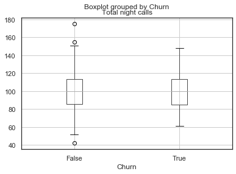

```python
plt.show()
df.boxplot(column='Total night calls', by='Churn')
```

```python
print('Maximum number of charge:',df['Total night charge'].max())
print('Minimum number of charge:',df['Total night charge'].min())
print('Average number of charge:',df['Total night charge'].mean())
```

```
Maximum number of charge: 16.55
Minimum number of charge: 1.04
Average number of charge: 8.985907046476756
```

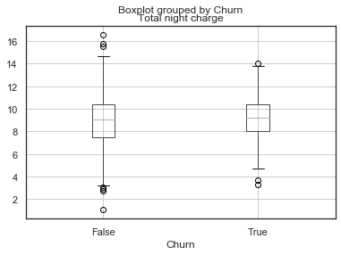

```python
plt.show()
df.boxplot(column='Total night charge', by='Churn')
```

Again Optimization of the charges can lead to reduce churned customers

# International Calls Affecting the Churn Rate

```python
print('Maximum number of minutes:',df['Total intl minutes'].max(),'i.e. Max number of Hours  spent:',round(df['Total intl minutes'].max()/60))
print('Minimum number of minutes:',df['Total intl minutes'].min())
print('Average number of minutes:',df['Total intl minutes'].mean())
```

```
Maximum number of minutes: 18.3 i.e. Max number of Hours  spent: 0
Minimum number of minutes: 0.0
Average number of minutes: 10.23838080959521
```

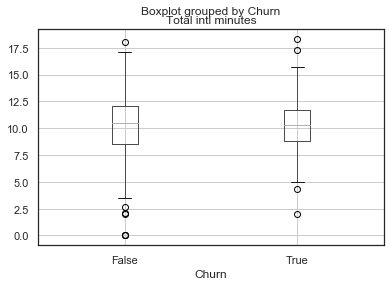

```python
plt.show()
df.boxplot(column='Total intl minutes', by='Churn')
```

Users who make the International Call tend to spend more minutes.

```python
print('Maximum number of calls:',df['Total intl calls'].max())
print('Minimum number of calls:',df['Total intl calls'].min())
print('Average number of calls:',df['Total intl calls'].mean())
```

```
Maximum number of calls: 18
Minimum number of calls: 0
Average number of calls: 4.527736131934033
```

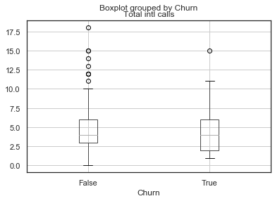

```python
plt.show()
df.boxplot(column='Total intl calls', by='Churn')
```

```python
print('Maximum number of charge:',df['Total intl charge'].max())
print('Minimum number of charge:',df['Total intl charge'].min())
print('Average number of charge:',df['Total intl charge'].mean())
```

```
Maximum number of charge: 4.94
Minimum number of charge: 0.0
Average number of charge: 2.7649475262368814
```

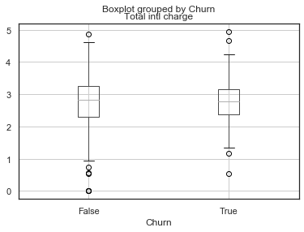

```python
plt.show()
df.boxplot(column='Total intl charge', by='Churn')
```

Different Pricing Strategy and International Calling Rate Optimization would lead to lower churn rate

# Churn According to States

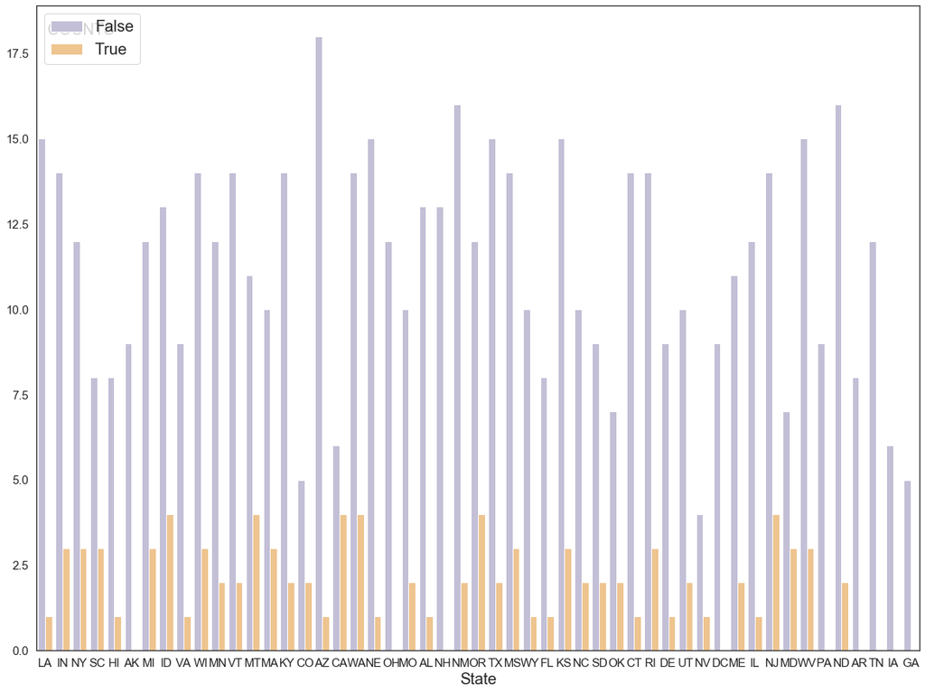

```python
# By Age
fig, axz = plt.subplots(figsize=(20,15))

axz = sns.countplot(x='State', hue='Churn', data=df, palette='PuOr_r')


axz.set_ylabel('COUNTS', rotation=0, labelpad=100,size=20)
axz.set_xlabel('State', size=20)
axz.yaxis.set_label_coords(0.05, 0.95)  # (x, y)
axz.legend(loc=0,fontsize=20);

axz.tick_params(labelsize=15)  # Changes size of the values on the label
```

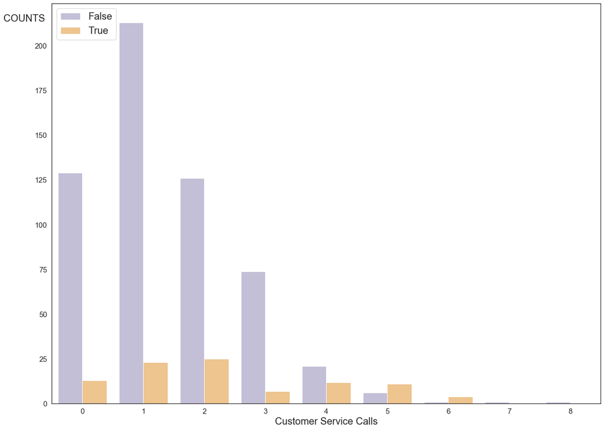

```python
# Customer Calls
fig, axz = plt.subplots(figsize=(20,15))

axz = sns.countplot(x='Customer service calls', hue='Churn', data=df, palette='PuOr_r')


axz.set_ylabel('COUNTS', rotation=0, labelpad=100,size=20)
axz.set_xlabel('Customer Service Calls', size=20)
axz.yaxis.set_label_coords(-0.05, 0.95)  # (x, y)
axz.legend(loc=0,fontsize=20);

axz.tick_params(labelsize=15)  # Changes size of the values on the label
```

1. A Feedback is neccesary in such situations.
2. It should given a Confirmation to the Customer that there issue would be solved in first attempt

```python
df['Churn'] = df['Churn'].replace({bool(True):1,bool(False):0})
```

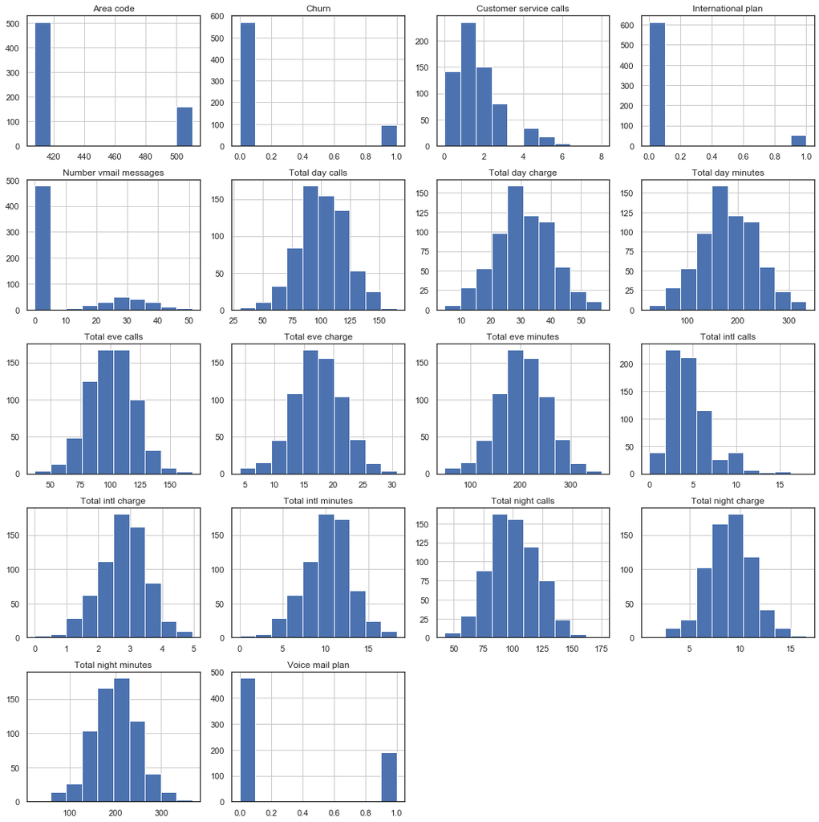

```python
# Freq distribution of all data
fig, ax = plt.subplots(figsize=(15,15))
pd.DataFrame.hist(df,ax=ax)
plt.tight_layout();
```

```python
day_df = df[['Total day minutes','Total day calls','Total day minutes','Total day charge','Churn']]
eve_df = df[['Total eve minutes','Total eve calls','Total eve minutes','Total eve charge','Churn']]
night_df = df[['Total night minutes','Total night calls','Total night minutes','Total night charge','Churn']]
intl_df = df[['Total intl minutes','Total intl calls','Total intl minutes','Total intl charge','Churn']]
```

```python
df.columns
```

```
Index(['State', 'Area code', 'International plan', 'Voice mail plan',
       'Number vmail messages', 'Total day minutes', 'Total day calls',
       'Total day charge', 'Total eve minutes', 'Total eve calls',
       'Total eve charge', 'Total night minutes', 'Total night calls',
       'Total night charge', 'Total intl minutes', 'Total intl calls',
       'Total intl charge', 'Customer service calls', 'Churn'],
      dtype='object')
```

# Data Correlation

```python
df.corr()
```

[output not shown]

[figure not shown]

```python
# Now that we have our features, let's plot them on a correlation matrix to remove anything that might
# cause multi-colinearity within our model

sns.set(style="white")
# Creating the data
data = df.corr()


# Generate a mask for the upper triangle
mask = np.zeros_like(data, dtype=np.bool)
mask[np.triu_indices_from(mask)] = True


# Set up the matplotlib figure to control size of heatmap
fig, ax = plt.subplots(figsize=(60,50))


# Create a custom color palette
cmap = \
sns.diverging_palette(138, 10,
                      as_cmap=True)
# as_cmap returns a matplotlib colormap object rather than a list of colors
# Green = Good (low correlation), Red = Bad (high correlation) between the independent variables
# Plot the heatmap
g = sns.heatmap(data=data, annot=True, cmap=cmap, ax=ax,
                mask=mask, # Splits heatmap into a triangle
                annot_kws={"size":20},  #Annotation size
               cbar_kws={"shrink": 0.8} # Color bar size
               );


# Prevent Heatmap Cut-Off Issue
bottom, top = ax.get_ylim()
ax.set_ylim(bottom + 0.5, top - 0.5)

# Changes size of the values on the label
ax.tick_params(labelsize=25)
ax.set_title("correlation matrix",fontsize= 60)
ax.set_yticklabels(g.get_yticklabels(), rotation=0);
ax.set_xticklabels(g.get_xticklabels(), rotation=10);
```

# 4.Fitting the model with different alogirithms

#### Training the model with following alogorithms :

```
    1. Logistic regression
    2. KNN
    3. Random forest classifier
```

```python
from sklearn.model_selection import train_test_split
from sklearn.linear_model import LogisticRegression
from sklearn.metrics import confusion_matrix,accuracy_score,classification_report
from sklearn.metrics import roc_auc_score,roc_curve,scorer
from sklearn.metrics import f1_score
import statsmodels.api as sm
from sklearn.metrics import precision_score,recall_score
```

```python
#splitting train and test data
train,test = train_test_split(df,test_size = .25 ,random_state = 111)
X = df.drop(['State','Churn'],axis=1)
target_col = ['Churn']
```

```python
##seperating dependent and independent variables
cols    = X.columns
train_X = train[cols]
train_Y = train[target_col]
test_X  = test[cols]
test_Y  = test[target_col]
```

# 1.Logistic Regression

```python
from sklearn.linear_model import LogisticRegression

logreg = LogisticRegression()
logreg.fit(train_X,train_Y)
```

```
LogisticRegression()
```

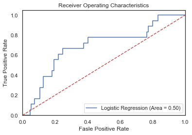

```python
from sklearn.metrics import roc_auc_score
from sklearn.metrics import roc_curve

y_pred_logreg = logreg.predict(test_X)

logreg_roc_auc = roc_auc_score(test_Y,y_pred_logreg)
fpr, tpr, thresholds = roc_curve(test_Y,logreg.predict_proba(test_X)[:,1])
plt.figure()
plt.plot(fpr, tpr, label='Logistic Regression (Area = %0.2f)' % logreg_roc_auc)
plt.plot([0,1],[0,1],'r--')
plt.xlim([0.0,1.0])
plt.ylim([0.0,1.05])
plt.xlabel('Fasle Positive Rate')
plt.ylabel('True Positive Rate')
plt.title('Receiver Operating Characteristics')
plt.legend(loc="lower right")
plt.savefig('LOG_ROC')
plt.show()
```

```python
print('Accuracy Score : ' + str(accuracy_score(test_Y,y_pred_logreg)))
print('Precision Score : ' + str(precision_score(test_Y,y_pred_logreg)))
print('Recall Score : ' + str(recall_score(test_Y,y_pred_logreg)))
print('F1 Score : ' + str(f1_score(test_Y,y_pred_logreg)))
```

```
Accuracy Score : 0.8502994011976048
Precision Score : 0.1111111111111111
Recall Score : 0.05555555555555555
F1 Score : 0.07407407407407407
```

```
confusion matrix of logistic regression :
 [[141   8]
 [ 17   1]]
```

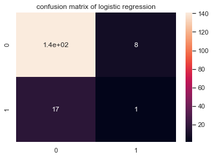

```python
from sklearn.metrics import confusion_matrix
confusion_matrix_logreg = confusion_matrix(test_Y,y_pred_logreg)
print("confusion matrix of logistic regression :\n",confusion_matrix_logreg )
ax = plt.axes()
sns.heatmap(confusion_matrix_logreg,annot=True)
ax.set_title('confusion matrix of logistic regression')
plt.show()
```

```python
from sklearn.metrics import classification_report
classify_logreg = classification_report(test_Y, y_pred_logreg)
print(classify_logreg)
```

```
              precision    recall  f1-score   support

           0       0.89      0.95      0.92       149
           1       0.11      0.06      0.07        18

    accuracy                           0.85       167
   macro avg       0.50      0.50      0.50       167
weighted avg       0.81      0.85      0.83       167
```

```
AxesSubplot(0.125,0.125;0.775x0.755)
```

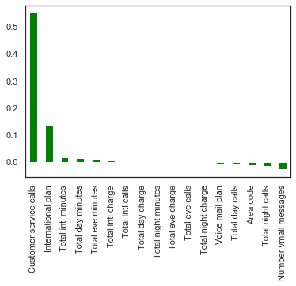

```python
# Weights of the variables

logweights = pd.Series(logreg.coef_[0], index=X.columns.values)
weight_logreg = logweights.sort_values(ascending = False)[:36].plot(kind='bar', color='green')
print (weight_logreg)
```

### Now we will compare with KNN and Random forest classifier

# 2. K Nearest Neighbors Classifier

```python
# K Nearest Neighbors Classifier

from sklearn.neighbors import KNeighborsClassifier

neighbors = np.arange(1,9)
train_accuracy =np.empty(len(neighbors))
test_accuracy = np.empty(len(neighbors))

for i,k in enumerate(neighbors):
    #Setup a knn classifier with k neighbors
    knn = KNeighborsClassifier(n_neighbors=k)

    #Fit the model
    knn.fit(train_X, train_Y)

    #Compute accuracy on the training set
    train_accuracy[i] = knn.score(train_X, train_Y)

    #Compute accuracy on the test set
    test_accuracy[i] = knn.score(test_X,test_Y)
```

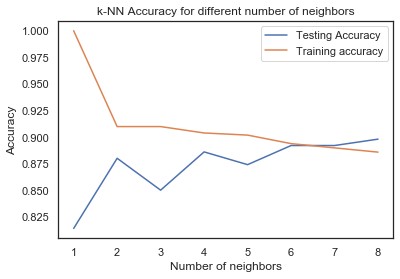

```python
plt.title('k-NN Accuracy for different number of neighbors')
plt.plot(neighbors, test_accuracy, label='Testing Accuracy')
plt.plot(neighbors, train_accuracy, label='Training accuracy')
plt.legend()
plt.xlabel('Number of neighbors')
plt.ylabel('Accuracy')
plt.show()
```

The accuracy is maximum for n = 8

```python
knn = KNeighborsClassifier(n_neighbors=8)
knn.fit( train_X,train_Y)
```

```
KNeighborsClassifier(n_neighbors=8)
```

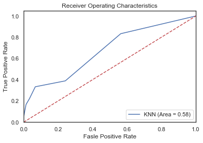

```python
y_pred_knn= knn.predict(test_X)
knn_roc_auc = roc_auc_score(test_Y,y_pred_knn)
fpr, tpr, thresholds = roc_curve(test_Y,knn.predict_proba(test_X)[:,1])
plt.figure()
plt.plot(fpr, tpr, label='KNN (Area = %0.2f)' % knn_roc_auc)
plt.plot([0,1],[0,1],'r--')
plt.xlim([0.0,1.0])
plt.ylim([0.0,1.05])
plt.xlabel('Fasle Positive Rate')
plt.ylabel('True Positive Rate')
plt.title('Receiver Operating Characteristics')
plt.legend(loc="lower right")
plt.savefig('KNN_ROC')
plt.show()
```

```python
print('Accuracy Score : ' + str(accuracy_score(test_Y,y_pred_knn)))
print('Precision Score : ' + str(precision_score(test_Y,y_pred_knn)))
print('Recall Score : ' + str(recall_score(test_Y,y_pred_knn)))
print('F1 Score : ' + str(f1_score(test_Y,y_pred_knn)))
```

```
Accuracy Score : 0.8982035928143712
Precision Score : 0.6
Recall Score : 0.16666666666666666
F1 Score : 0.2608695652173913
```

```
confusion matirx of KNN:
 [[147   2]
 [ 15   3]]
```

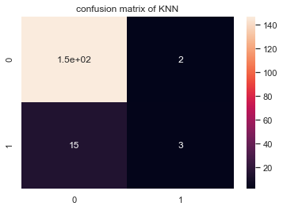

```python
confusion_matrix_knn = confusion_matrix(test_Y,y_pred_knn)
print("confusion matirx of KNN:\n",confusion_matrix_knn )
ax = plt.axes()
sns.heatmap(confusion_matrix_knn ,annot=True)
ax.set_title('confusion matrix of KNN')
plt.show()
```

```python
classify_knn = classification_report(test_Y, y_pred_knn)
print(classify_knn)
```

```
              precision    recall  f1-score   support

           0       0.91      0.99      0.95       149
           1       0.60      0.17      0.26        18

    accuracy                           0.90       167
   macro avg       0.75      0.58      0.60       167
weighted avg       0.87      0.90      0.87       167
```